# PolyAIA — worked example

## Summary plots

A four-panel overview of the RED results: how many polyA sites the analyzed genes carry, how the tested pairs split between intronic (REDi) and exonic (REDu) events, and the direction of the significant shifts in one cell type.

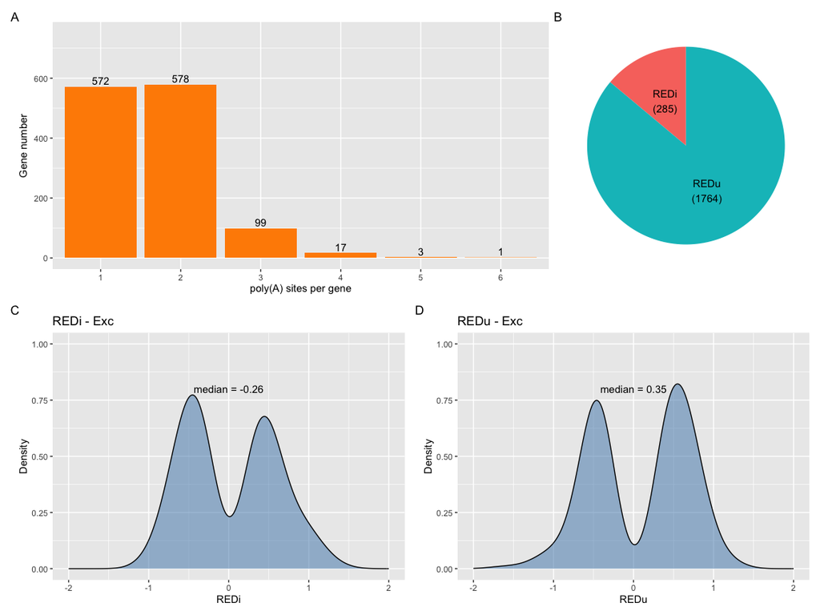

```r
library(ggplot2)
library(dplyr)
library(patchwork)

### A. polyA sites per gene ---------------------------------------------------
# One row per gene (npas is gene-level, so distinct() avoids counting a gene
# once per pair/cell type/comparison). Genes with 10+ sites are pooled into "M".
p_npas <- red_scores %>%
  distinct(Gene_symbol, npas) %>%
  mutate(
    npas_bin = ifelse(npas >= 10, "M", as.character(npas)),
    npas_bin = factor(npas_bin, levels = c(as.character(1:9), "M"))
  ) %>%
  count(npas_bin) %>%
  ggplot(aes(x = npas_bin, y = n)) +
  ylim(0,750) +
  geom_col(fill = "darkorange") +
  geom_text(aes(label = n), vjust = -0.3) +
  labs(x = "poly(A) sites per gene", y = "Gene number")

### B. REDi vs REDu composition -----------------------------------------------
# Pie chart of the tested proximal/distal pairs in Exc: REDi = the proximal
# site is intronic, REDu = both sites are in the 3' most exon.
p_redtype <- red_scores %>%
  filter(Cells == "Exc" ) %>%
  count(RED_type) %>%
  ggplot(aes(x = "", y = n, fill = RED_type)) +
  geom_col(width = 1) +
  coord_polar(theta = "y") +
  geom_text(aes(label = paste0(RED_type, "\n(", n, ")")), position = position_stack(vjust = 0.5)) +
  theme_void() +
  theme(legend.position = "none")

### C. REDi distribution (Exc) --------------------------------------------
# Density of significant intronic events (|RED| > 0.25, padj < 0.1). The median
# annotation shows whether the shift is globally towards lengthening (> 0) or
# shortening (< 0).
df_redi <- red_scores %>%
  filter(Cells == "Exc" & abs(RED) > 0.25 & RED_LRT_padj < 0.1 & RED_type == "REDi")

p_redi_l23 <- df_redi %>%
  ggplot(aes(x = RED)) +
  xlim(-2,2) +
  ylim(0,1) +
  geom_density(fill = "steelblue", alpha = 0.5) +
  annotate("text", x = 0, y = 0.8, label = paste0("median = ", round(median(df_redi$RED), 2))) +
  labs(title = "REDi - Exc", x = "REDi", y = "Density")

### D. REDu distribution (Exc) --------------------------------------------
# Same for exonic (3' UTR) events, on identical axes so C and D are directly
# comparable.
df_redu <- red_scores %>%
  filter(Cells == "Exc" & abs(RED) > 0.25 & RED_LRT_padj < 0.1 & RED_type == "REDu")

p_redu_l23 <- df_redu %>%
  ggplot(aes(x = RED)) +
  xlim(-2,2) +
  ylim(0,1) +
  geom_density(fill = "steelblue", alpha = 0.5) +
  annotate("text", x = 0, y = 0.8, label = paste0("median = ", round(median(df_redu$RED), 2))) +
  labs(title = "REDu - Exc", x = "REDu", y = "Density")

### Assemble ------------------------------------------------------------------
( p_npas | p_redtype ) / ( p_redi_l23 | p_redu_l23) +
  plot_annotation(tag_levels = "A")
```

## Canonical vs. modified residuals

`modified_residuals` selects which implementation computes the polyA residuals that the differential test runs on:

- `FALSE` (default) — `PASTA::CalcPolyAResiduals()`, the canonical version;
- `TRUE` — this package’s `CalcPolyAResidualsPolyA()`.

Both write the residuals to the polyA assay’s `scale.data` layer, so everything downstream is identical; only the PASTA statistics (`p_estimate_PASTA`, `PASTA_padj`, …) can differ. Re-running with the other implementation shows how much that choice actually moves the results.

```r
set.seed(100)

deps_mod <- PolyAIA::DEPsMatrix(
  seu             = seurat_polyA,
  comparisons     = comparisons,
  genomic_positions = c("3' most exon", "Intron", "Intergenic"),
  celltype_col    = "CellType",
  condition_cols  = c("Treatment", "Strain"),
  group.by        = c("Strain", "Treatment", "CellType", "Number"),
  gene.names      = "Gene_Symbol",

  background      = "ControlB6",
  background_cols = c("Treatment", "Strain"),
  background_sep  = "",
  min.counts.background = 5,

  Pasta              = TRUE,
  modified_residuals = TRUE,     # <-- the only difference from the run above
  min_cells       = 10,
  filter_method   = "edgeR",
  repeat_masker   = "Remove",
  rmsk            = rmsk,
  return_seurat   = FALSE
)
```

[output not shown]

```r
red_scores_mod <- deps_mod$red_scores
```

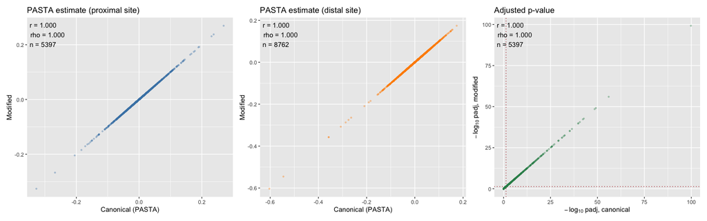

```r
library(ggplot2)
library(dplyr)
library(patchwork)

# A row is one proximal/distal pair in one cell type and comparison, so
# (Cells, Condition, p_peak, d_peak) identifies it uniquely. The pairing step
# uses counts, not residuals, so the same pairs are expected in both runs --
# an inner_join() therefore keeps everything they have in common and quietly
# drops any pair that only one run produced.
cmp_df <- dplyr::inner_join(
  red_scores     %>% select(Cells, Condition, p_peak, d_peak,
                            p_est_canon = p_estimate_PASTA,
                            d_est_canon = d_estimate_PASTA,
                            padj_canon  = PASTA_padj),
  red_scores_mod %>% select(Cells, Condition, p_peak, d_peak,
                            p_est_mod = p_estimate_PASTA,
                            d_est_mod = d_estimate_PASTA,
                            padj_mod  = PASTA_padj),
  by = c("Cells", "Condition", "p_peak", "d_peak")
)

message(sprintf("Pairs shared by both runs: %d (canonical: %d, modified: %d)",
                nrow(cmp_df), nrow(red_scores), nrow(red_scores_mod)))

# Correlation label: Pearson measures agreement in magnitude, Spearman in rank.
# Both are reported because they can disagree when a few pairs shift a lot.
corr_label <- function(x, y) {
  ok <- is.finite(x) & is.finite(y)
  if (sum(ok) < 3) return("n < 3")
  sprintf("r = %.3f\nrho = %.3f\nn = %d",
          cor(x[ok], y[ok], method = "pearson"),
          cor(x[ok], y[ok], method = "spearman"),
          sum(ok))
}

### A. PASTA estimate, proximal site ------------------------------------------
# Effect size for the proximal site of each pair.
p_est <- ggplot(cmp_df, aes(x = p_est_canon, y = p_est_mod)) +
  geom_point(alpha = 0.3, size = 0.8, colour = "steelblue") +
  annotate("text", x = -Inf, y = Inf, hjust = -0.1, vjust = 1.2,
           label = corr_label(cmp_df$p_est_canon, cmp_df$p_est_mod)) +
  labs(title = "PASTA estimate (proximal site)",
       x = "Canonical (PASTA)", y = "Modified")

### B. PASTA estimate, distal site --------------------------------------------
# Same for the distal site. Worth plotting separately: the residual model is
# fitted per polyA site, so the two slots of a pair are not guaranteed to be
# perturbed to the same degree by a change of implementation.
d_est <- ggplot(cmp_df, aes(x = d_est_canon, y = d_est_mod)) +
  geom_point(alpha = 0.3, size = 0.8, colour = "darkorange") +
  annotate("text", x = -Inf, y = Inf, hjust = -0.1, vjust = 1.2,
           label = corr_label(cmp_df$d_est_canon, cmp_df$d_est_mod)) +
  labs(title = "PASTA estimate (distal site)",
       x = "Canonical (PASTA)", y = "Modified")

### C. Adjusted p-value -------------------------------------------------------
# On -log10 scale, so the significant end of the range is the readable one.
# Zero p-values would become Inf, so they are floored at the smallest
# non-zero value present.
floor_p <- function(p) {
  nz <- p[is.finite(p) & p > 0]
  pmax(p, if (length(nz)) min(nz) else .Machine$double.xmin)
}

cmp_padj <- cmp_df %>%
  filter(is.finite(padj_canon), is.finite(padj_mod)) %>%
  mutate(lp_canon = -log10(floor_p(padj_canon)),
         lp_mod   = -log10(floor_p(padj_mod)))

p_padj <- ggplot(cmp_padj, aes(x = lp_canon, y = lp_mod)) +
  geom_hline(yintercept = -log10(0.05), linetype = "dotted", colour = "firebrick") +
  geom_vline(xintercept = -log10(0.05), linetype = "dotted", colour = "firebrick") +
  geom_point(alpha = 0.3, size = 0.8, colour = "seagreen") +
  annotate("text", x = -Inf, y = Inf, hjust = -0.1, vjust = 1.2,
           label = corr_label(cmp_padj$lp_canon, cmp_padj$lp_mod)) +
  labs(title = "Adjusted p-value",
       x = expression(-log[10]~"padj, canonical"),
       y = expression(-log[10]~"padj, modified"))

p_est | d_est | p_padj
```

How often the two implementations agree on significance at padj < 0.05 — the off-diagonal cells are the pairs whose call changes:

```r
table(canonical = cmp_padj$padj_canon < 0.05,
      modified  = cmp_padj$padj_mod   < 0.05)
```

```
         modified
canonical FALSE TRUE
    FALSE  4255    7
    TRUE      0 1135
```

# 2. Coverage visualization

`PolyAPlot()` draws coverage tracks with the gene’s polyA sites, peaks and transcript annotation. `cell_filter` selects which cells to show (a broad class or a list of subpopulations) and `bulk = TRUE` collapses them into one track; `condition` restricts the plotted region and site labels to one comparison, and adding `condition_group_cols` also restricts the coverage cells to the two groups being compared.

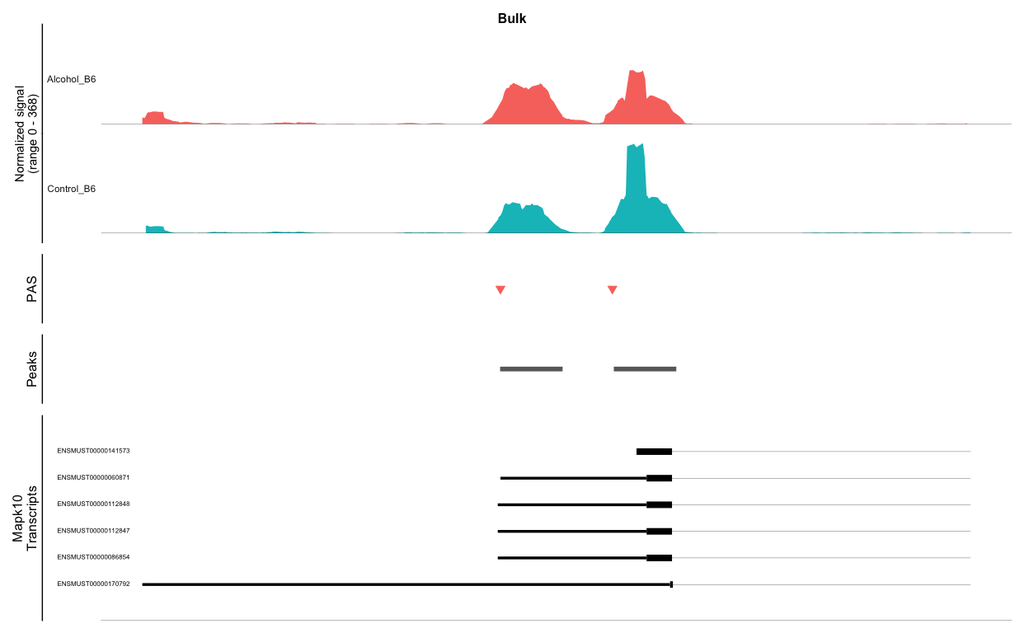

```r
PolyAIA::PolyAPlot(
  seu       = seurat_polyA,
  gene      = "Mapk10",
  deg_list  = red_scores[red_scores$RED_type == "REDu",],
  polyAdb   = polyAdb,
  species   = "mouse",
  version   = "mm10",
  expand_bp = 2000,
  polyARegion = TRUE,

  cell_filter = "L2/3 IT",            # keep excitatory neurons
  cell_order = c("L2/3 IT"),
  bulk        = TRUE,             # ...as one combined track
  group.by    = "Strain",
  split.by    = "Treatment",

  condition            = "B6_Alcohol_vs_B6_Control",
  condition_group_cols = c("Strain", "Treatment")
)
```

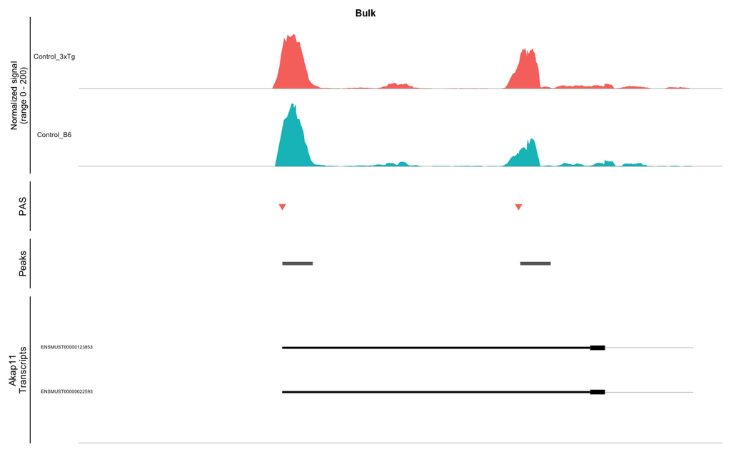

```r
PolyAIA::PolyAPlot(
  seu       = seurat_polyA,
  gene      = "Akap11",
  deg_list  = red_scores[red_scores$RED_type == "REDu",],
  polyAdb   = polyAdb,
  species   = "mouse",
  version   = "mm10",
  expand_bp = 2000,
  polyARegion = TRUE,

  cell_filter = "L2/3 IT",            # keep excitatory neurons
  cell_order = c("L2/3 IT"),
  bulk        = TRUE,             # ...as one combined track
  group.by    = "Strain",
  split.by    = "Treatment",

  condition            = "3xTg_Control_vs_B6_Control",
  condition_group_cols = c("Strain", "Treatment")
)
```

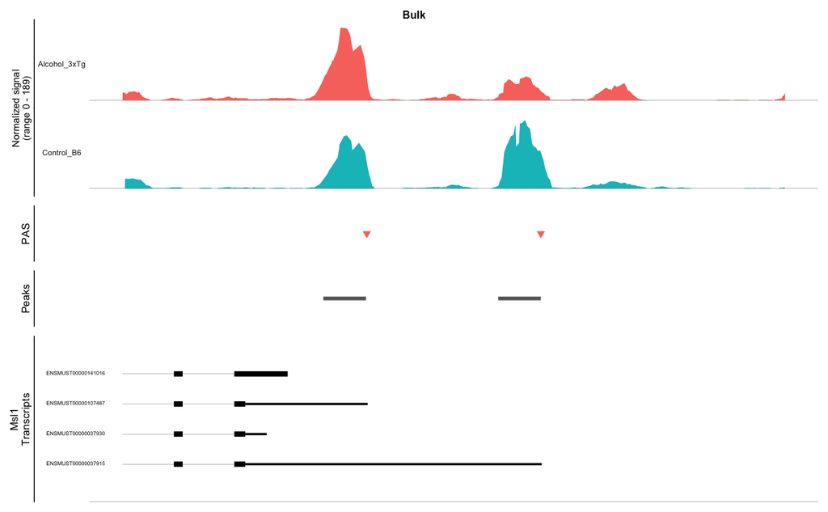

```r
PolyAIA::PolyAPlot(
  seu       = seurat_polyA,
  gene      = "Msl1",
  deg_list  = red_scores[red_scores$RED_type == "REDu",],
  polyAdb   = polyAdb,
  species   = "mouse",
  version   = "mm10",
  expand_bp = 2000,
  polyARegion = TRUE,

  cell_filter = "L2/3 IT",            # keep excitatory neurons
  cell_order = c("L2/3 IT"),
  bulk        = TRUE,             # ...as one combined track
  group.by    = "Strain",
  split.by    = "Treatment",

  condition            = "3xTg_Alcohol_vs_B6_Control",
  condition_group_cols = c("Strain", "Treatment")
)
```

# 3. Workflow used to generate Seurat_polyA object

How the example object was built, and the QC / integration / visualization helpers. The steps that need the raw 10X `.h5` files, polyA peak counts and fragment files are shown as non-evaluated reference (`eval = FALSE`); the plotting sections run on the object loaded above.

## 3.1 From 10X to an annotated Seurat object

```r
seurat_obj <- PolyAIA::UploadSce(
  data_dir        = "../../Mice_example/2_h5_files/",
  file_pattern    = ".h5",
  metadata_file   = "../../Mice_example/4_MetaData/Metada_sanna.csv",
  species         = "mouse",
  reference       = "mousecortexref",   # Azimuth -> CellType / Subpopulation
  column_id       = "Sample_accession",
  genome_build    = "mm10",
  IDtype          = "ENSEMBL",
  remove_doublets = TRUE
)
```

```r
# `thresholds` is the per-cell-type table defined in 3.2 below.
seurat_obj <- PolyAIA::SeuratPipeline(seurat_obj, sample_col = "Sample")
```

## 3.2 Quality control

`QCPlot()` shows the three standard metrics (`nCount_RNA`, `nFeature_RNA`, `percent_mito`). Passing cutoffs draws them as dashed reference lines, and `split_by` facets by any metadata column.

```r
PolyAIA::QCPlot(seurat_obj, split_by = "CellType")
```

[output not shown]

### Per-cell-type filtering

RNA content differs a lot between populations — neurons carry far more transcripts than microglia or oligodendrocytes — so a single global cutoff over-filters the low-RNA types and under-filters the high-RNA ones. `QCFilter()` applies a **different threshold per cell type**: each cell is matched to its group’s row and dropped only if it fails a bound for *its own* type. Any threshold column you omit simply isn’t enforced.

```r
thresholds <- data.frame(
  CellType     = c("Astro",  "End", "Exc",  "Inh",      "Mic",  "Oligo", "OPC"),
  min_counts   = c( 1000,     400,   2200,   1500,        250,      250,   250),
  max_counts   = c( 5000,    5000,   9000,   9000,       5000,     5000,  5000),
  min_features = c( 1000,     400,   2200,   1500,        250,      250,   250),
  max_features = c( 3000,    2000,   4000,   4000,       2000,     2000,  3000),
  mito_cutoff  = c(    3,       3,      3,      3,          3,        3,     3)
)

seurat_obj <- PolyAIA::QCFilter(seurat_obj, thresholds, group_col = "CellType")
```

```r
PolyAIA::QCPlot(seurat_obj, split_by = "CellType")
```

[output not shown]

## 3.3 Cell-type visualization

```r
PolyAIA::UmapPlot(
  seurat_obj, "harmony",
  color           = "CellType",
  label_by        = "CellType",
  show_labels     = TRUE,
  legend.position = "right"
)
```

[output not shown]

`DotPlot()` converts rownames to gene symbols internally (using the assay’s `SYMBOL` feature metadata), so it works whether the object was built with Ensembl IDs or symbols.

```r
Gene_type_markers <- list(
  Astro = c("Gfap", "Aqp4", "Aldh1l1", "Gja1", "Slc1a3"),
  Exc   = c("Slc17a7", "Satb2"),
  Inh   = c("Gad1", "Gad2"),
  Mic   = c("C1qa", "C1qb", "C1qc", "Csf1r", "Cx3cr1"),
  Oligo = c("Plp1", "Mbp", "Mobp", "Mog", "Mag"),
  OPC   = c("Pdgfra", "Cspg4", "Sox10", "Olig1", "Olig2")
)

PolyAIA::DotPlot(
  seu       = seurat_obj,
  group_var = "CellType",
  features  = Gene_type_markers,
  dot_scale = 3,
  sizes     = c(7, 0.5, 9, 7)
)
```

[output not shown]

## 3.5 Building and attaching the polyA assay

```r
library(PASTA); library(Signac); library(EnsDb.Mmusculus.v79)
options(Seurat.object.assay.calcn = TRUE)

counts_dir <- "../../Mice_example/3_polyA_counts/"
samples <- unique(gsub("\\.tab\\.gz$", "", list.files(counts_dir, pattern = "\\.tab\\.gz$")))

# One sample at a time -- keeps peak memory low
polyA.assays <- PolyAIA::UploadPolyAAssays(
  samples       = samples,
  counts_dir    = counts_dir,
  peaks_file    = "../../Mice_example/4_MetaData/polyA_Bam_Files_polyA_peaks.gff",
  fragments_dir = "../../Mice_example/1_Mice_bed_files.nosync/",
  min.features  = 500,
  min.cells     = 50,
  genome        = "mm10"
)

# Unify peaks across samples, then requantify everyone against that set
PeaksFiltering <- PolyAIA::FilterPeaks(polyA.assays, multiple_samples = FALSE)

load("rds_files/Eviroment_seurat.RData")

for (i in seq_along(polyA.assays)) {
  cells <- intersect(colnames(seurat_obj), colnames(polyA.assays[[i]]))
  polyA.assays[[i]] <- subset(polyA.assays[[i]], cells = cells)
}


polyA.unified <- PolyAIA::RequantifyPolyA(
  polyA.assays  = polyA.assays,
  unified.peaks = PeaksFiltering,
  threshold     = 16,
  genome        = "mm10"
)

rm(polyA.assays)

polyA.merged <- merge(polyA.unified[[1]], polyA.unified[-1], merge.data = TRUE)

rm(polyA.unified)

annotations <- Signac::GetGRangesFromEnsDb(ensdb = EnsDb.Mmusculus.v79)
Signac::genome(annotations) <- "mm10"
Signac::Annotation(polyA.merged) <- annotations

cells <- intersect(colnames(seurat_obj), colnames(polyA.merged))
seurat_obj <- subset(seurat_obj, cells = cells)
seurat_obj[["polyA"]] <- subset(polyA.merged, cells = cells)
DefaultAssay(seurat_obj) <- "polyA"

rm(polyA.merged)

# Annotate sites against the polyA reference database
seurat_obj <- PASTA::GetPolyADbAnnotation(
  seurat_obj,
  polyAdb.file = "../../Mice_example/4_MetaData/polyAdb_mm10.txt",
  max.dist     = 50
)

# The example workspace bundles the object together with the RepeatMasker
# table, so section 4 can run straight after load().
rmsk <- read.delim("../../Mice_example/4_MetaData/mm10.rmsk.txt")
```